# Part II - Ford GoBike System Data Analysis

### by *Mlungiseleli Notshokovu*

## Investigation Overview

The goal of this presentation is to visualize key insights derived from the Bike Share Trip data.

## (Visualization 1)

A histogram showing that the age of most members is between 20-40. This could suggest that a lot of the members use bikes for most of their travels throughout the day, i.e commuting to work, going to the nearest coffee shop, etc

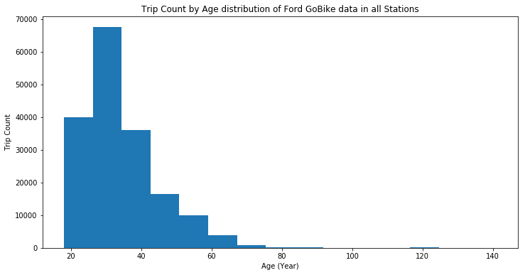

## (Visualization 2)

Now we want to see what happens when the number of bins increase to get a more clear picture of the age distribution.

- The distribution clearly shows that on average, members are between 30-40 years

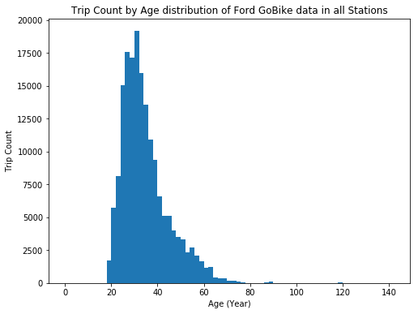

## (Visualization 3)

- A lot of trips occur in the morning, with a consistent spread during the afternoon and evening
- Not a lot of trips occur during the night

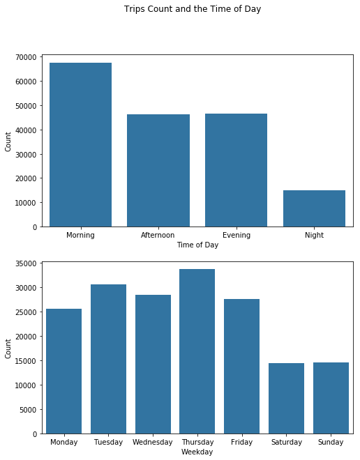

## (Visualization 4)

Bar graph showing the spread of gender across the two user types

- There are more Subscribers compared to Customers
- There are more Male users compared to Females

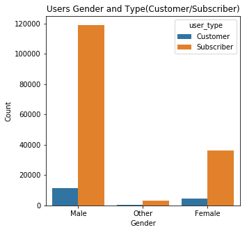

## (Visualization 5)

Pie Chart showing the spread of genders across all users

- 75% of users are Male
- 23% of users are Female
- 2% of users are 'Other' (gender not specified)

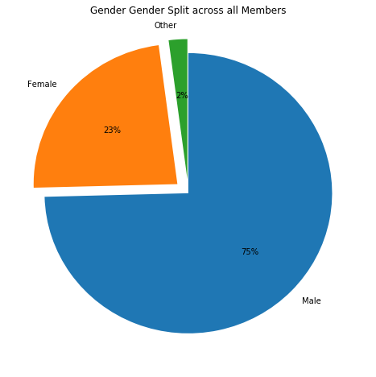

## (Visualization 6)

Line graph show the relationship spread of trip duration by user type (Customer/Subscriber) throughout the week

- Customers have a higher average trip duration than Subscribers
- There is a huge increase of Customer trip duration over the weekend
- Subscribers have a consistent trip duration throughout the week

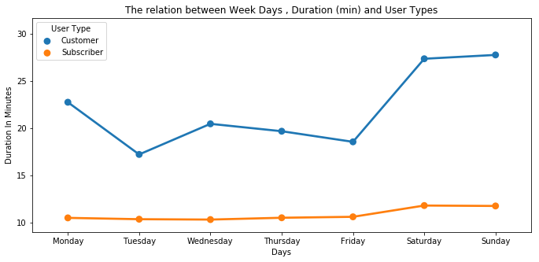

[output not shown]